# CS 422 Homework 8

Xingli Li

## Homework 8

### Part 2

set work space and install dependent package.

```r
library(cluster)
library(factoextra)
setwd(getwd())
```

### 2.1-(a)-(i)

```r
#  "I", "i", "C", "c", "P", "p", "M", "m", is the tooth pattern, the
#  number of top incisors, bottom incisors, top canines, bottom canines,
#  top premolars, bottom premolars, top molars, and bottom molars.

df <- read.csv("file19.csv", encoding = 'UTF-8')
X <- df[,-1]
X.scaled <- scale(X,center = FALSE)
```

Think of what attributes, if any, you may want to omit from the dataset when you do the clustering. Indicate all of the attributes you removed before doing the clustering.

Answer:

```
remove "name" of the attributes.
```

### 2.1-(a)-(ii)

Does the data need to be standardized? (Briefly, using 1-2 sentences, support your answer.)

Answer:

```
Yes, although they are all the teeth counts of the animals ,and the unit of measurement is the same, standardization can compress each attribute value into a smooth range, make the data distribution smoother and more natural.
```

### 2.1-(a)-(iii)

You will have to clean the data to remove multiple spaces and make the comma character the delimiter. Please make sure you include your cleaned dataset in the archive file you upload.

Answer:

[output not shown]

```r
head(df)
```

|  | Name | top.incisors | bottom.incisors | top.canines | bottom.canines | top.premolars | bottom.premolars | top.molars | bottom.molars |
| --- | --- | --- | --- | --- | --- | --- | --- | --- | --- |
| 1 | Opossum | 5 | 4 | 1 | 1 | 3 | 3 | 4 | 4 |
| 2 | Hairy tail mole | 3 | 3 | 1 | 1 | 4 | 4 | 3 | 3 |
| 3 | Common mole | 3 | 2 | 1 | 0 | 3 | 3 | 3 | 3 |
| 4 | Star nose mole | 3 | 3 | 1 | 1 | 4 | 4 | 3 | 3 |
| 5 | Brown bat | 2 | 3 | 1 | 1 | 3 | 3 | 3 | 3 |
| 6 | Silver hair bat | 2 | 3 | 1 | 1 | 2 | 3 | 3 | 3 |

### 2.1-(b)-(i)

Determine how many clusters are needed by running the WSS or Silhouette graph. Plot the graph using fviz_nbclust().

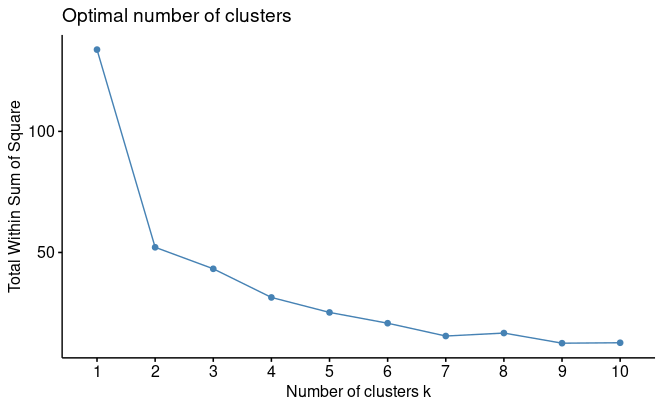

```r
# Elbow method minimizes total within-cluster sum of squares (wss).
fviz_nbclust(X.scaled, kmeans, method="wss")
```

Answer:

### 2.1-(b)-(ii)

Once you have determined the number of clusters, run k-means clustering on the dataset to create that many clusters. Plot the clusters using fviz_cluster().

```r
km <- kmeans(X.scaled, centers=4, nstart = 8)
km
```

```
K-means clustering with 4 clusters of sizes 20, 17, 20, 9

Cluster means:
  top.incisors bottom.incisors top.canines bottom.canines top.premolars bottom.premolars top.molars bottom.molars
1        0.483           0.357       0.000           0.00         0.403            0.291      1.189         1.142
2        1.110           1.126       1.291           1.26         1.052            1.155      1.054         1.055
3        1.311           0.958       1.291           1.34         1.192            1.145      0.384         0.545
4        0.000           1.502       0.287           0.00         1.052            1.090      1.097         1.055

Clustering vector:
 [1] 2 2 2 2 2 2 2 2 2 2 2 1 1 1 1 1 1 1 1 1 1 1 1 1 1 1 1 1 1 1 1 2 2 2 2 3 2 3 3 3 3 3 3 3 3 3 3 3 3 3 3 3 3 3 3 3 2 4 4 4 4 4 4 4 4 4

Within cluster sum of squares by cluster:
[1] 9.85 9.49 6.03 2.59
 (between_SS / total_SS =  79.1 %)

Available components:

[1] "cluster"      "centers"      "totss"        "withinss"     "tot.withinss" "betweenss"    "size"         "iter"         "ifault"
```

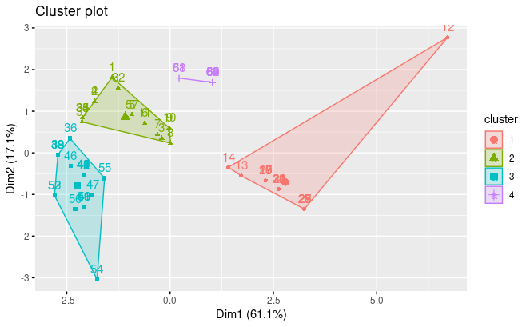

```r
fviz_cluster(km, data=X.scaled)
```

### 2.1-(b)-(iii)

How many observations are in each cluster?

```r
clusters <- c(1,2,3,4)

for (no in clusters){
  print(paste("cluster",no,"are",km$size[no],"observations"))
}
```

```
[1] "cluster 1 are 20 observations"
[1] "cluster 2 are 17 observations"
[1] "cluster 3 are 20 observations"
[1] "cluster 4 are 9 observations"
```

### 2.1-(b)-(iv)

What is the total SSE of the clusters?

```r
print(paste("The total SSE of the clusters is", round(km$totss,digits = 3)))
```

[output not shown]

### 2.1-(b)-(v)

What is the SSE of each cluster?

```r
clusters <- c(1,2,3,4)

for (no in clusters){
  print(paste("The SSE of the cluster", no,"is", round(km$withinss[no],digits = 3)))
}
```

```
[1] "The SSE of the cluster 1 is 9.855"
[1] "The SSE of the cluster 2 is 9.494"
[1] "The SSE of the cluster 3 is 6.026"
[1] "The SSE of the cluster 4 is 2.593"
```

### 2.1-(b)-(vi)

Perform an analysis of each cluster to determine how the mammals are grouped in each cluster, and whether that makes sense? Act as the domain expert here; clustering has produced what you asked it to. Examine the results based on your knowledge of the animal kingdom and see whether the results meet expectations. Provide me a summary of your observations.

```r
# clusters:

clusters <- c(1,2,3,4)

for (no in clusters) {
  print(df[which(km$cluster == no),])
}
```

|  | Name | top.incisors | bottom.incisors | top.canines | bottom.canines | top.premolars | bottom.premolars | top.molars | bottom.molars |
| --- | --- | --- | --- | --- | --- | --- | --- | --- | --- |
| 12 | Armadillo | 0 | 0 | 0 | 0 | 0 | 0 | 8 | 8 |
| 13 | Pika | 2 | 1 | 0 | 0 | 2 | 2 | 3 | 3 |
| 14 | Snowshoe rabbit | 2 | 1 | 0 | 0 | 3 | 2 | 3 | 3 |
| 15 | Beaver | 1 | 1 | 0 | 0 | 2 | 1 | 3 | 3 |
| 16 | Marmot | 1 | 1 | 0 | 0 | 2 | 1 | 3 | 3 |
| 17 | Groundhog | 1 | 1 | 0 | 0 | 2 | 1 | 3 | 3 |
| 18 | Prairie Dog | 1 | 1 | 0 | 0 | 2 | 1 | 3 | 3 |
| 19 | Ground Squirrel | 1 | 1 | 0 | 0 | 2 | 1 | 3 | 3 |
| 20 | Chipmunk | 1 | 1 | 0 | 0 | 2 | 1 | 3 | 3 |
| 21 | Gray squirrel | 1 | 1 | 0 | 0 | 1 | 1 | 3 | 3 |

[output cut: 10 more lines]

|  | Name | top.incisors | bottom.incisors | top.canines | bottom.canines | top.premolars | bottom.premolars | top.molars | bottom.molars |
| --- | --- | --- | --- | --- | --- | --- | --- | --- | --- |
| 1 | Opossum | 5 | 4 | 1 | 1 | 3 | 3 | 4 | 4 |
| 2 | Hairy tail mole | 3 | 3 | 1 | 1 | 4 | 4 | 3 | 3 |
| 3 | Common mole | 3 | 2 | 1 | 0 | 3 | 3 | 3 | 3 |
| 4 | Star nose mole | 3 | 3 | 1 | 1 | 4 | 4 | 3 | 3 |
| 5 | Brown bat | 2 | 3 | 1 | 1 | 3 | 3 | 3 | 3 |
| 6 | Silver hair bat | 2 | 3 | 1 | 1 | 2 | 3 | 3 | 3 |
| 7 | Pigmy bat | 2 | 3 | 1 | 1 | 2 | 2 | 3 | 3 |
| 8 | House bat | 2 | 3 | 1 | 1 | 1 | 2 | 3 | 3 |
| 9 | Red bat | 1 | 3 | 1 | 1 | 2 | 2 | 3 | 3 |
| 10 | Hoary bat | 1 | 3 | 1 | 1 | 2 | 2 | 3 | 3 |

[output cut: 7 more lines]

|  | Name | top.incisors | bottom.incisors | top.canines | bottom.canines | top.premolars | bottom.premolars | top.molars | bottom.molars |
| --- | --- | --- | --- | --- | --- | --- | --- | --- | --- |
| 36 | Civet cat | 3 | 3 | 1 | 1 | 4 | 4 | 2 | 2 |
| 38 | Marten | 3 | 3 | 1 | 1 | 4 | 4 | 1 | 2 |
| 39 | Fisher | 3 | 3 | 1 | 1 | 4 | 4 | 1 | 2 |
| 40 | Weasel | 3 | 3 | 1 | 1 | 3 | 3 | 1 | 2 |
| 41 | Mink | 3 | 3 | 1 | 1 | 3 | 3 | 1 | 2 |
| 42 | Ferrer | 3 | 3 | 1 | 1 | 3 | 3 | 1 | 2 |
| 43 | Wolverine | 3 | 3 | 1 | 1 | 4 | 4 | 1 | 2 |
| 44 | Badger | 3 | 3 | 1 | 1 | 3 | 3 | 1 | 2 |
| 45 | Skunk | 3 | 3 | 1 | 1 | 3 | 3 | 1 | 2 |
| 46 | River otter | 3 | 3 | 1 | 1 | 4 | 3 | 1 | 2 |

[output cut: 10 more lines]

|  | Name | top.incisors | bottom.incisors | top.canines | bottom.canines | top.premolars | bottom.premolars | top.molars | bottom.molars |
| --- | --- | --- | --- | --- | --- | --- | --- | --- | --- |
| 58 | Elk | 0 | 4 | 1 | 0 | 3 | 3 | 3 | 3 |
| 59 | Deer | 0 | 4 | 0 | 0 | 3 | 3 | 3 | 3 |
| 60 | Moose | 0 | 4 | 0 | 0 | 3 | 3 | 3 | 3 |
| 61 | Reindeer | 0 | 4 | 1 | 0 | 3 | 3 | 3 | 3 |
| 62 | Antelope | 0 | 4 | 0 | 0 | 3 | 3 | 3 | 3 |
| 63 | Bison | 0 | 4 | 0 | 0 | 3 | 3 | 3 | 3 |
| 64 | Mountain goat | 0 | 4 | 0 | 0 | 3 | 3 | 3 | 3 |
| 65 | Musk ox | 0 | 4 | 0 | 0 | 3 | 3 | 3 | 3 |
| 66 | Mountain sheep | 0 | 4 | 0 | 0 | 3 | 3 | 3 | 3 |

Answer:

[output not shown]